# Final Project

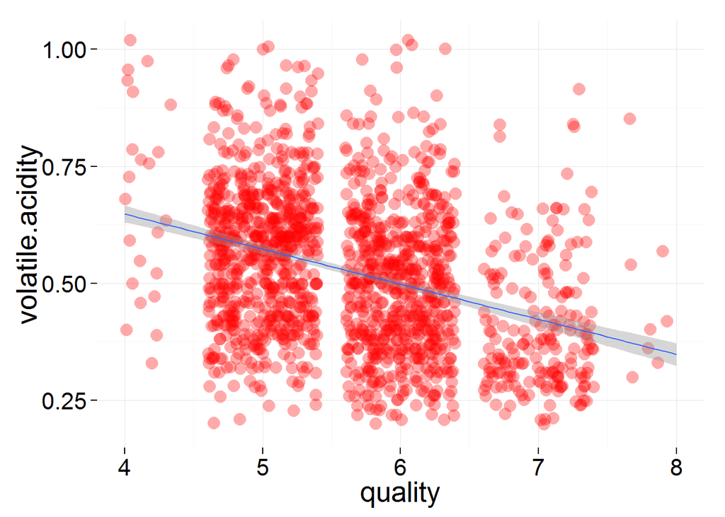

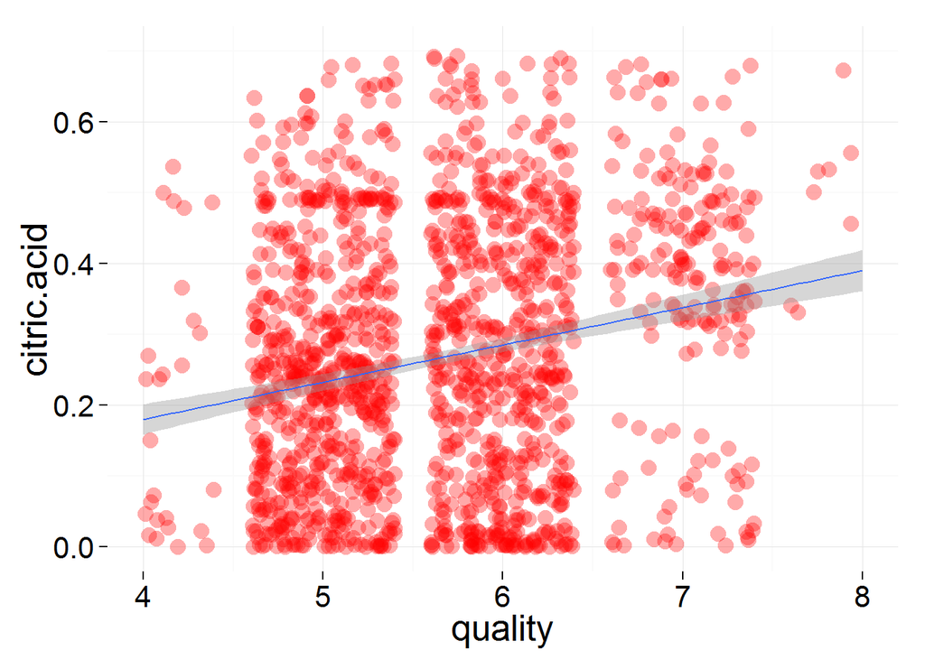

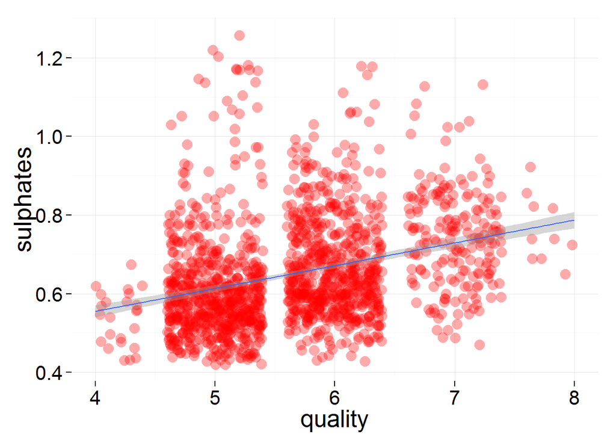

While looking at the fixed.acidity vs citric.acid plot I realised there are many wines with citric.acid ~0.5 and some with ~0.25, which I didn’t notice in the initial histograms. Also, while plotting the scatterplots with the quality variable, as it is a discrete variable, I thought about plotting the average alcohol/volatile.acidity/citric.acid/sulphates amount per quality level, I’ll do that in the next section.

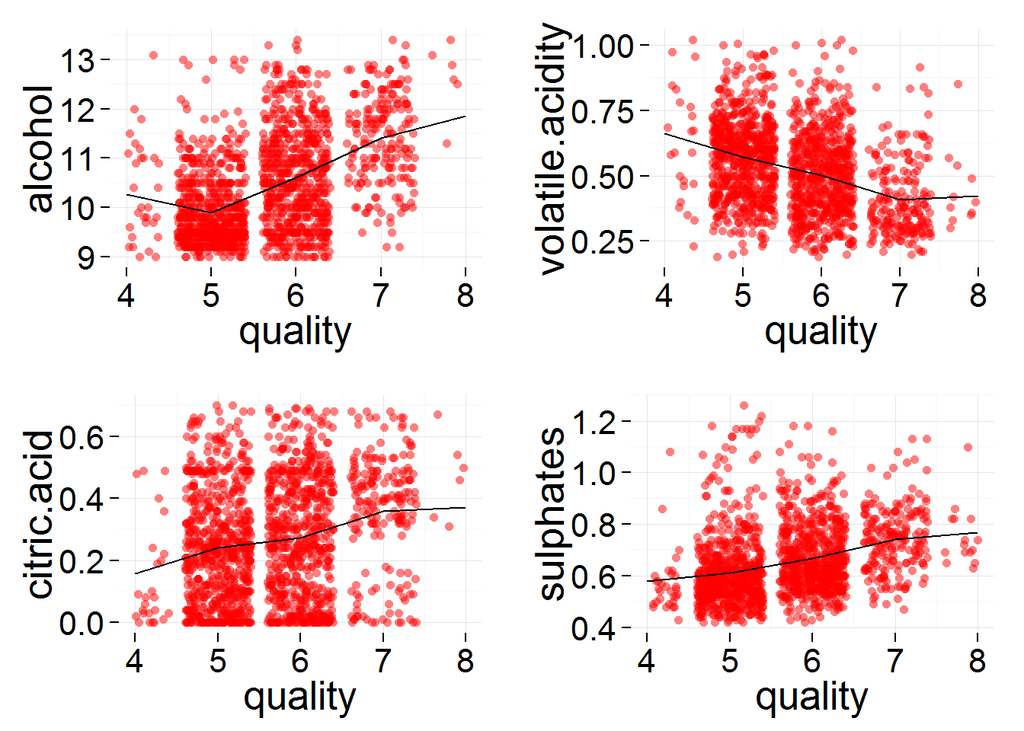

Alcohol seems to be the variable that contributes the most to quality. Let’s see a boxplot of alcohol per quality rank.

# Final plots

### Boxplot for alcohol and quality

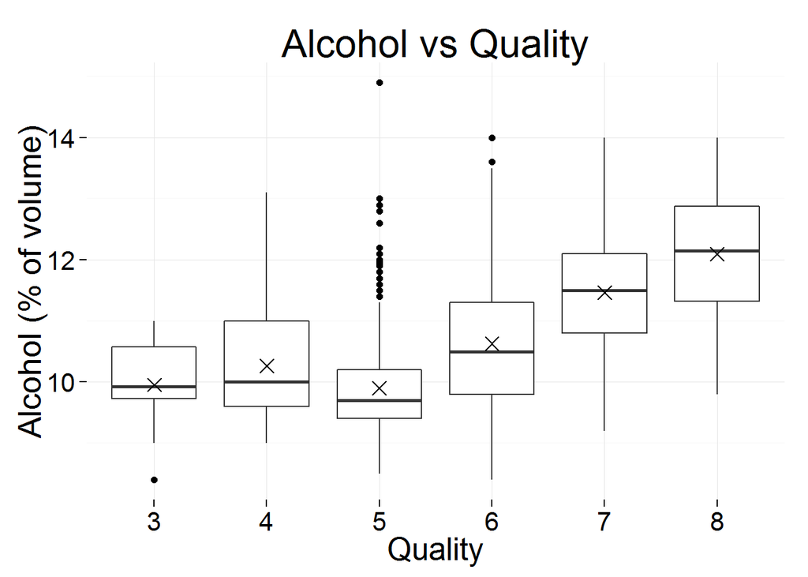

```r
summary(wines$alcohol[wines$quality == 3])
```

```
##    Min. 1st Qu.  Median    Mean 3rd Qu.    Max.
##   8.400   9.725   9.925   9.955  10.580  11.000
```

```r
summary(wines$alcohol[wines$quality == 4])
```

```
##    Min. 1st Qu.  Median    Mean 3rd Qu.    Max.
##    9.00    9.60   10.00   10.27   11.00   13.10
```

```r
summary(wines$alcohol[wines$quality == 5])
```

```
##    Min. 1st Qu.  Median    Mean 3rd Qu.    Max.
##     8.5     9.4     9.7     9.9    10.2    14.9
```

```r
summary(wines$alcohol[wines$quality == 6])
```

```
##    Min. 1st Qu.  Median    Mean 3rd Qu.    Max.
##    8.40    9.80   10.50   10.63   11.30   14.00
```

```r
summary(wines$alcohol[wines$quality == 7])
```

```
##    Min. 1st Qu.  Median    Mean 3rd Qu.    Max.
##    9.20   10.80   11.50   11.47   12.10   14.00
```

```r
summary(wines$alcohol[wines$quality == 8])
```

```
##    Min. 1st Qu.  Median    Mean 3rd Qu.    Max.
##    9.80   11.32   12.15   12.09   12.88   14.00
```

### Description

We can clearly see a trend here. From average wines (quality == 5), the alcohol content starts to grow in better wines. I added the mean (cross) to the plot, this way the representation conveys all the information contained in the summaries, but much more effectively.

### Frequency polygon for quality

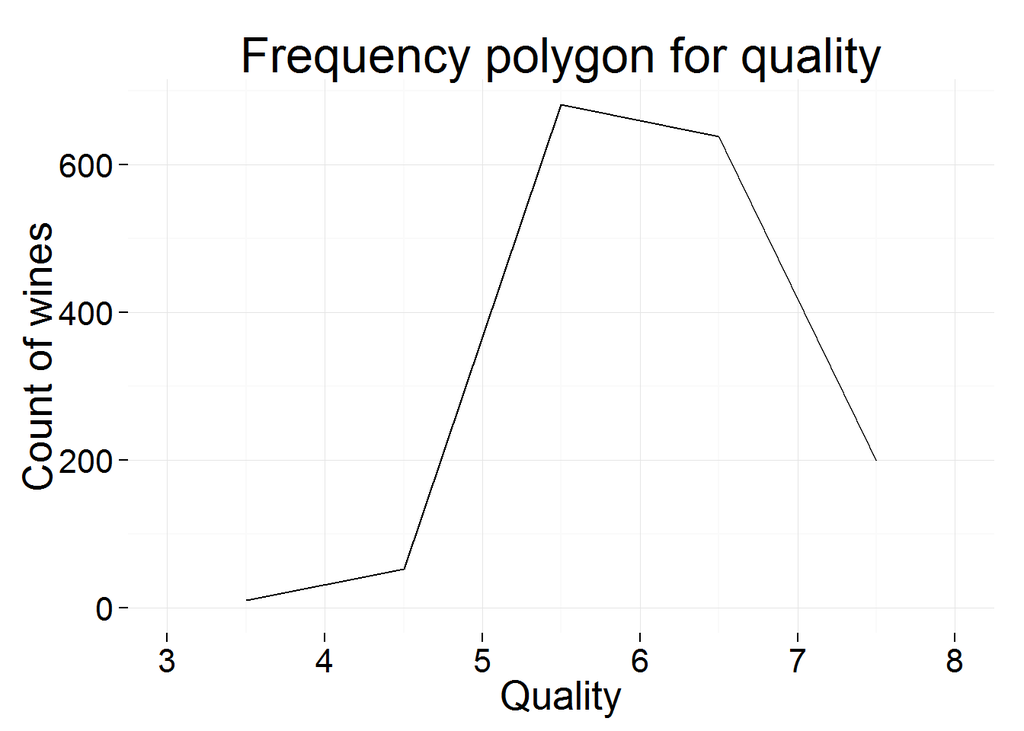

```
##    Min. 1st Qu.  Median    Mean 3rd Qu.    Max.
##   3.000   5.000   6.000   5.636   6.000   8.000
```

### Description

Here we see that most of the wines are labeled as average or good (~6) quality. We saw in the variable summary that the median was 6 and the mean was 5.636. This plot also tells us that this dataset contains limited information on very good or very bad wines, therefore it would be difficult to extend our conclussions with a high degree of certainty to these wines, or create accurate predictive models.

### Scatterplot for fixed.acidity and density by quality

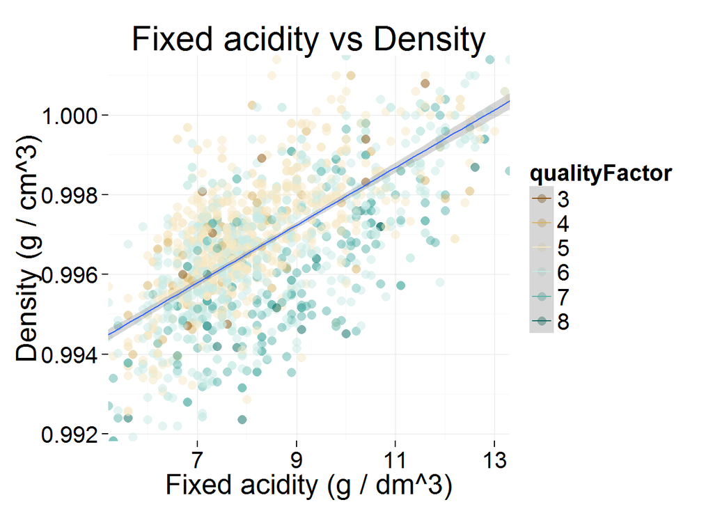

### Description

The fixed acidity increases with the density, but also, specially after adding the smoother, we can see than the highest quality wines (bluish) are usually below this line indicating lower density for these wines. I chose this plot to see the relation between two of the variables with a higher correlation colored by quality, and the color helped to discover that density correlates negatively with wine quality. We can visually see this with the following extra boxplot.

### Extra: Density vs Quality boxplot

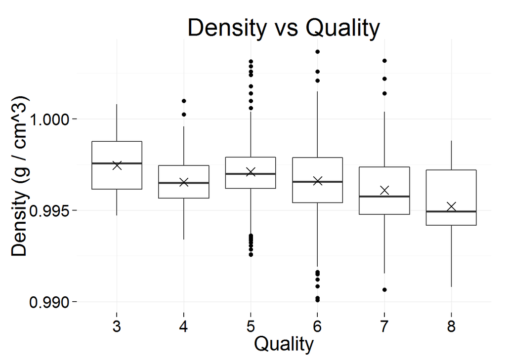

# Reflection

After exploring the dataset I can say, looking at the most correlated variables, that the most density a wine has the less alcohol it has, being this last variable the single highest predictor for wine quality, although still not being very highly correlated. Also, most of the wines were rated slightly above medium quality (5). I’d say that with these variables alone it would be difficult to generate a highly reliable model to predict quality. Adding smoothers to the plots was a great improvement as it wasn’t easy to see the trend in most of them. Looking for similar datasets I found some other variables that could have been useful predictors in our case, such as type of grapes or amount of rain for that year, along with some other weather and soil conditions. Adding those variables to the dataset could contribute to better models.